# IE-582 Project Report

Serhat Arca - Ahmet Coşgun - Elif Erdinç

6 January 2019

# 1. Introduction

**Machine learning (ML)** is one of the best methodologies for prediction and forecasting applications and has been accepted in various communities due to promising results obtained. Using the power of ML has been also adopted in sports forecasting. Regarding the large monetary amounts involved in betting, necessity of high accuracy forecasting is obvious. Besides, there are several factors dominating the results of game scores such as club managers and owners, performances of individual players, historical knowledge of games etc. Formulating the effects of each components would help to find out the key parameters in the success.

In this project, it is aimed to develop a machine-learning algorithm that predicts the probabilities for the upcoming matches in **English Premiere League (EPL)**. In the extent of the project, home – tie – away outcome probabilities for **80 matches (8 rounds) from 30.11.2018 to 03.01.2019** are predicted and submitted according to time schedule.

There are two given datasets:

**1.** The odd-details data include the odds for 27 bookmakers and 6 bets type (1x2, ah, bts, dc, ha, ou) listed with corresponding match ID and date. The final version of this dataset has 7,527,087 instances starting from August 2010 with 7 columns.

**2.** The match data stores the information about the soccer games played in the league since August 2010 for 3529 matches. The home and away teams with match scores are given with corresponding match ID and date.

In the selection of the features, considering the requirement to predict home – tie – away probabilities of match results, odd-details data is filtered for 1x2 type of bets since it includes the knowledge of home – tie – away match results so that 1, x, and 2 represent the home, tie, and away, respectively. Since bookmakers set their odds based on the knowledge of the current status of the teams, players, home/away conditions etc., they carry quite well information about the match outcomes. However, *the final 5 match performances of the teams* are also added as features.

As a methodology, first, data preprocessing step is applied on both match and odd-details datasets. In odd-details dataset, game result type of bets (1x2) are chosen for 25 bookmakers, opening and closing odds are taken as different features. Then, feature elimination is performed regarding a certain missing data threshold limit. From match dataset, 12 new features are added which are average goals scored by home and away teams, average goals conceded by home and away teams, percentage of wins, ties, and loses by home and away teams, total points gathered by home and away teams.

Three most commonly used ML algorithms, **Elastic Net (glmnet), Random Forest (caret, method: rf), Stochastic Gradient Boosting (caret, method: xgbtree)**, are performed. Their optimal parameters are determined on train data applying *10-fold cross-validation*.

Three metrics are studied to compare the results of these three algorithms. Based on RPS calculations, the most powerful prediction is obtained by Elastic Net algorithm.

# 2. Related Literature

The popularity of online sports betting is increasing due to widespread use of internet. This brings up a great interest in the analysis and forecasting of competitive sports among scientists. Two types of information are usually used for forecasting purposes. One type of information is the ratings of the competitors’ strengths whereas the second type of information comes from the odds given by bookmakers for winning a match **(Leitner et. al, 2010)**.

The ratings are assigned to teams based on their past performance in order to predict future match results. One study that makes use of this method belongs to Suzuki and Ohmori, in which they used Fifa/Coca Cola rankings to predict the results of World Cup USA 94, France 98, Japan/Korea 2002 and Germany 2006 **(Suzuki and Ohmori, 2008)**. Another rating system that is used by researchers is the ELO system, which was originally used for ranking chess players. In their study, Hvattum and Arntzen used ELO ratings for match result prediction in soccer **(Hvattum and Arntzen, 2010)**. They used ELO rating differences as covariates in ordered logit regression models and compared their models with six benchmark prediction models. Their results indicated that, the ELO- based method was significantly worse than the two methods that made use of market odds and was better than the rest of the methods. In another study, Wunderlich and Memmert used an approach that combined the ELO rating system with the betting odds **(Wunderlich and Memmert, 2018)**. They used around 15000 games between 2007/2008 to 2016/2017 season. Their results indicated that the novel betting odds based ELO model outperformed classic ELO models.

Previous research has shown that betting odds are usually yields better results compared to mathematical models in sports forecasting. In their study, Forrest et. al made use of 10000 English soccer game to compare the effectiveness of forecasts based on published odds and forecasts based on statistical models **(Forrest et. Al, 2005)**. Their results indicated that the forecasts based on the bookmaker odds cannot be outperformed by statistical models. In their study, Strumbelj and Sikonja studied the effectiveness of using online bookmakers for forecasting purposes **(Strumbelj and Sikonja, 2010)**. In order to do that, they analyzed 10699 matches from 6 different leagues and the corresponding odds from 10 different online bookmakers. Their results indicated that using the odds from online bookmakers for forecasting purposes has become more effective over the time. They also found that the performance of the same bookmaker is different for different leagues. In another study, Baboota and Kaur used feature engineering and data analysis to create a forecasting model (Baboota and Kaur, In press). They used several machine learning algorithms and found that the best results were obtained with gradient boosting, followed by random forest and support vector machine. They used ranked probability score (RPS) to compare their results with some betting organizations and observed that their model was outperformed by the bookmakers. In their study, Leitner et. al, studied the effectiveness of a model based on bookmakers’ odds and models based on ELO rating and FIFA/Coca Cola World ranking to forecast the EURO 2008 results. Their results indicated that the model based on the bookmakers’ odds outperform both of the other models **(Leitner et. al, 2010)**. In another study, Goddord and Asimakopoulos built an ordered probit regression model to predict the outcomes of the English Premier League games **(Goddord and Asimakopoulos, 2004)**. Their results indicated that, in addition to past match results, features such as involvement of the teams in cup competition, geographical distance between the home towns and average attendances of the teams effect the model performance. Spann and Skiera compared the predictive accuracy of different methods, namely prediction markets, tipsters and betting odds **(Spann and Skiera, 2009)**. They used data from the 3 seasons of German premier league. Their results indicated that prediction markets and betting odds are similar in terms of forecasting accuracy and they outperform forecasts from tipsters. In another study, Strumbelj compared the accuracies of forecasts by making use of probabilities determined from betting odds using Shin’s model, basic normalization and regression models **(Strumbelj, 2014)**. His results indicated that probabilities obtained by Shin’s method yield more accurate results compared to the other methods that are used.

# 3. Proposed Approach

This section is written based on the final version of the code.

## 3.1. Data preprocessing

Match data and odd-details data are preprocessed using custom made preprocessing functions. In both datasets, the instances **dated older than August 2013** are eliminated since old data does not reflect the today’s predictions. In odd-details dataset, bookmakers “BetFairExchange” and “PaddyPower” are removed as their missing data is too much. The bet type 1x2 is selected and features are formed for each home – tie – away odds for each maker. The opening and closing odds for remaining 25 bookmakers are taken as features for model construction. Eventually, every match becomes a instance. In odd-details data preprocessing, the parameter for removing bookmaker odds with **missing ratio greater than threshold 0.01** is chosen to deal with missing data issue, this threshold decreased **the number of bookmakers from 25 to 12**.

```r
testStart=as.Date('2018-11-29')
trainStart=as.Date('2013-08-10')
rem_miss_threshold=0.01 #parameter for removing bookmaker odds with missing ratio greater than this threshold
```

In match dataset preprocessing, it is noticed that some team names are written in differently, so first miswritten team names are fixed.

```r
matches$Home <- gsub('manchester-united', 'manchester-utd', matches$Home)
matches$Away <- gsub('manchester-united', 'manchester-utd', matches$Away)

matches$Home <- gsub('crystal palace', 'crystal-palace', matches$Home)
matches$Away <- gsub('crystal palace', 'crystal-palace', matches$Away)

matches$Home <- gsub('manchester city', 'manchester-city', matches$Home)
matches$Away <- gsub('manchester city', 'manchester-city', matches$Away)

matches$Home <- gsub('manchester united', 'manchester-utd', matches$Home)
matches$Away <- gsub('manchester united', 'manchester-utd', matches$Away)

matches$Home <- gsub('newcastle utd', 'newcastle', matches$Home)
matches$Away <- gsub('newcastle utd', 'newcastle', matches$Away)

matches$Home <- gsub('stoke city', 'stoke', matches$Home)
matches$Away <- gsub('stoke city', 'stoke', matches$Away)

matches$Home <- gsub('west ham', 'west-ham', matches$Home)
matches$Away <- gsub('west ham', 'west-ham', matches$Away)
```

From literature, some **team related features** are found based on the home and away teams. These are average goals scored by home and away teams, average goals conceded by home and away teams, percentage of wins, ties, and loses by home and away teams, total points gathered by home and away teams. This data is summarized in a way that home team statistics are taken from the **last 5 games** of home team played at home and vice versa. To look at the previous matches, *“lag”* function of *“dplyr”* package is used which eliminates the empty instances of not played games. From the same package, *“rollsum”* function is used for averaging the last N games.

The following code segments shows the calculation of team specific features where data is prepared from the average of N previous matches.N is chosen as 5, and saved as *averageofhowmanygames*.

```r
averageofhowmanygames<-5
t2 = t2 %>%
 group_by(Home) %>%
 arrange(Match_Date.x) %>%
 mutate(HHome_Score.lag = lag(Home_Score, n = 1),
        HResult_Home.lag = lag(Result_Home, n = 1),
        HResult_Tie.lag = lag(Result_Tie, n = 1),
        HResult_Away.lag = lag(Result_Away, n = 1),
        HAway_Score.lag = lag(Away_Score, n = 1))
t2<-t2%>%arrange(desc(Match_Date.x))
df2 = t2 %>%
 group_by(Home) %>%
 arrange(Match_Date.x) %>%
 mutate(temp.1 = rollsum(x = HHome_Score.lag, averageofhowmanygames, align = "right", fill = NA),
        temp.2 = rollsum(x = HResult_Home.lag, averageofhowmanygames, align = "right", fill = NA),
        temp.3 = rollsum(x = HResult_Tie.lag, averageofhowmanygames, align = "right", fill = NA),
        temp.4 = rollsum(x = HResult_Away.lag, averageofhowmanygames, align = "right", fill = NA),
        temp.5 = rollsum(x = HAway_Score.lag, averageofhowmanygames, align = "right", fill = NA))
df2<-df2%>%arrange(desc(Match_Date.x))
```

## 3.2. Model Construction

The data is separated as train and test data based on the match date. Earlier the test date beginning set, larger the number of test data. Train data is used to optimize the parameters of the models. After optimizing each model using the train set, the test results are used to compare the different ML algorithms used in model construction.

```r
# divide data based on the provided dates
train_features=features[Match_Date>=trainStart & Match_Date<testStart]
test_features=features[Match_Date>=testStart]
```

Regarding the literature, the most promising 3 ML algorithms are selected and applied: Elastic Net (glmnet), Random Forest (caret, method rf), Stochastic Gradient Boosting (SGB) (caret, method xgbtree). For all methods, separate functions are written in which the models parameters are tried to be optimized by 10-fold cross-validation in training set.

The following code section shows the functions of these algorithms. The functions themselves are added to the appendix.

```r
# run glmnet on train data with tuning lambda parameter based on RPS and return predictions based on lambda with minimum RPS
predictions=train_glmnet(train_features, test_features,not_included_feature_indices=c(1:5), alpha=0.5,nlambda=50, tune_lambda=TRUE,nofReplications=2,nFolds=10,trace=T)

# run xgboost from caret package
predictions_xg=train_xgboost(train_features, test_features,not_included_feature_indices=c(1:5),nFolds=10,trace=T)

# run randomforest from caret package
predictions_rf=train_rfboost(train_features, test_features,not_included_feature_indices=c(1:5),nFolds=10,trace=T)
```

In **glmnet**, elastic net mixing parameter of alpha means how ridge and Lasso regressions are weighed where alpha equals to 0 means ridge, whereas alpha equals to 1 means Lasso penalized regression. **Alpha values of 0, 0.5, and 1 are tried** and the best test results are obtained for alpha equals to 0.5. In the loop, sequence of **lambda values are tried and optimized**.

In **random forest**, train function of caret package is used to optimize **the minimal number of observations per tree leaf (mtry)**.

In **extreme gradient boosting**, similar to random forest approach, train function is utilized to find optimal **depth of tree, learning rate, number of trees, and minimum number of observations per tree leaf** are found.

## 3.3. Model Evaluation Metrics

In order to compare the performances of the models in terms of prediction powers, several indications are considered. One of them is *Ranked Probability Score (RPS)*, which is a measure of how good the score is forecasted, and it is calculated via the below formula:

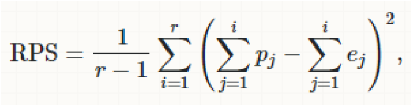

**Figure 1** - Formulation of RPS

The second one is the *confusion matrix* by accepting that the maximum probability of an output is the final result of the match. In other words, if the maximum probability is obtained for home among home, tie, and away; home will have 1, tie and away will have 0 probabilities.

The third approach is based on the forecasting power of games actually finished home win, tie, and away win. Thus, home, tie, and away prediction capabilities of three ML algorithms can be compared.

# 4. Results

One of the parameters changed is the start date of the dataset. The original data starts from August 2010. However, performances of the teams may change over the years, and considering the very past information may worsen the prediction power of models. Trying several starting dates, **August 2013** is decided to be followed in both odd-details and match data.

Another parameter varied to improve the test accuracy is the **missing data removal threshold limit**. It has been changed from 0.005 to 0.1, and **0.01** is determined as the final threshold and this leave us with 96 features extracted from odd-details data.

One major indicator of the success of the model is the RPS. As mentioned above, RPS shows how the predicted probabilities satisfies the match outcomes. Regarding the fact that lower the RPS, higher the model accuracy, below RPS results yield that elastic net algorithm (glmnet) gives better predictions.

The following results are computed by separating test set from the start of the first round for the project, until the end of the last round (which accounts for 80 matches).

Result of RPS calculation for each match as matrix and a combined value as a single value:

```
## # A tibble: 80 x 3
##    glmnet    xgb     rf
##     <dbl>  <dbl>  <dbl>
##  1 0.167  0.128  0.145
##  2 0.129  0.132  0.0936
##  3 0.375  0.350  0.331
##  4 0.313  0.329  0.336
##  5 0.347  0.364  0.277
##  6 0.103  0.106  0.120
##  7 0.139  0.142  0.151
##  8 0.398  0.428  0.407
##  9 0.0469 0.0265 0.0495
## 10 0.0291 0.0240 0.0271
## # ... with 70 more rows
```

```
## # A tibble: 1 x 3
##   glmnet   xgb    rf
##    <dbl> <dbl> <dbl>
## 1  0.134 0.143 0.138
```

As mentioned under the “Data Preprocessing” title, 12 new features (108 features in total) are created from the match results. These are showing teams’ home and away performances in their last 5 matches. Models are reconstructed with all 108 features, and resulting RPSs are recalculated.

Result of RPS calculation for each match as matrix and a combined value as a single value with added features:

```
## # A tibble: 80 x 3
##    glmnet    xgb     rf
##     <dbl>  <dbl>  <dbl>
##  1 0.0654 0.0535 0.0709
##  2 0.153  0.187  0.216
##  3 0.490  0.605  0.527
##  4 0.232  0.280  0.186
##  5 0.131  0.134  0.172
##  6 0.221  0.216  0.173
##  7 0.526  0.593  0.584
##  8 0.417  0.519  0.438
##  9 0.316  0.373  0.316
## 10 0.189  0.187  0.170
## # ... with 70 more rows
```

```
## # A tibble: 1 x 3
##   glmnet   xgb    rf
##    <dbl> <dbl> <dbl>
## 1  0.134 0.141 0.137
```

When two feature sets (96 vs 108 features) are compared, it is seen that increasing the number of features improved the RPS for random forest and the xgboost algorithms but did not changed for the glmnet predictions. This can be explained with the fact that features coming from the odd data already includes the information about the performances of the teams. Therefore, by applying a penalized regression on a dataset with correlated features did not improved the predictive power of the model.

Another metric that e used for the model comparison is confusion matrix. The confusion matrix is prepared y accepting that the highest probability of a match outcome (home - tie - away) is the predicted outcome of the match. The confusion matrices of three models studied are given as:

Confusion matrix for *elastic net*:

```
##           Reference
## Prediction Away Home Tie
##       Away   14    8   2
##       Home   15   30  11
##       Tie     0    0   0
```

```
##       Accuracy          Kappa  AccuracyLower  AccuracyUpper   AccuracyNull
##    0.550000000    0.194630872    0.434673979    0.661513616    0.475000000
## AccuracyPValue  McnemarPValue
##    0.109149201    0.001708509
```

Confusion matrix for *extreme gradient boosting*:

```
##           Reference
## Prediction Away Home Tie
##       Away   15    9   3
##       Home   13   28   9
##       Tie     1    1   1
```

```
##       Accuracy          Kappa  AccuracyLower  AccuracyUpper   AccuracyNull
##     0.55000000     0.21696574     0.43467398     0.66151362     0.47500000
## AccuracyPValue  McnemarPValue
##     0.10914920     0.04345331
```

Confusion matrix for *random forest*:

```
##           Reference
## Prediction Away Home Tie
##       Away   15    5   3
##       Home   10   30   8
##       Tie     4    3   2
```

```
##       Accuracy          Kappa  AccuracyLower  AccuracyUpper   AccuracyNull
##     0.58750000     0.30379747     0.47184834     0.69647541     0.47500000
## AccuracyPValue  McnemarPValue
##     0.02849862     0.25271838
```

From confusion matrix, the overal accuracy shows that the highest accuracy is achieved by random forest algorithm. Also it can be seen that, glmnet algorithm didn’t predicted a match outcome as “Tie”, meaining, this algorithm never gave tie outcome the highest probability.

The errors made by all algorithms are very similar with each other. In all of them the biggest misprediction for away wins are meade in the favor of home team. The mispredictions of tie results also shows the same pattern, which mispredicts tie results as home win. In general most of the predictions are made in the favor of home win, and tie results are always underestimated.

The following table shows the averages of each observed(real) results versus the probability given to that result by each algorithm. It can be concluded that although randomforest algorithm has slightly more higher given probablity for home result, glmnet gives higher probabilities for tie and away.

The overall probabilities of each algorithm splitted by the actual game result:

```
##               Home       Tie      Away
## glmnet   0.5502178 0.2596830 0.4484620
## XGBcaret 0.5605141 0.2477659 0.4173132
## RFcaret  0.5646842 0.2460000 0.4275172
```

The following plot shows the individual game in the test set in the x-coordinate, whereas in y-coordinate the given probablities for actual games results are given. It also suggest that tie results are poorly predicted in each algorithm compared to home and away wins.

Plot of matches vs probabilities of actual outcomes:

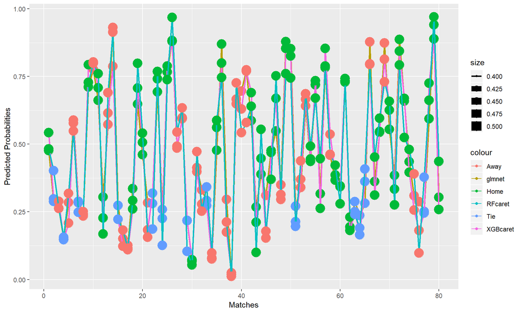

The following plot is the same without the dots , emphasizing the difference in algorithms with different colored lines. Almost in all cases glmnet (denoted with pink line) has a stronger predictive power for the actual game result.

Plot of matches vs probabilities of actual outcomes:

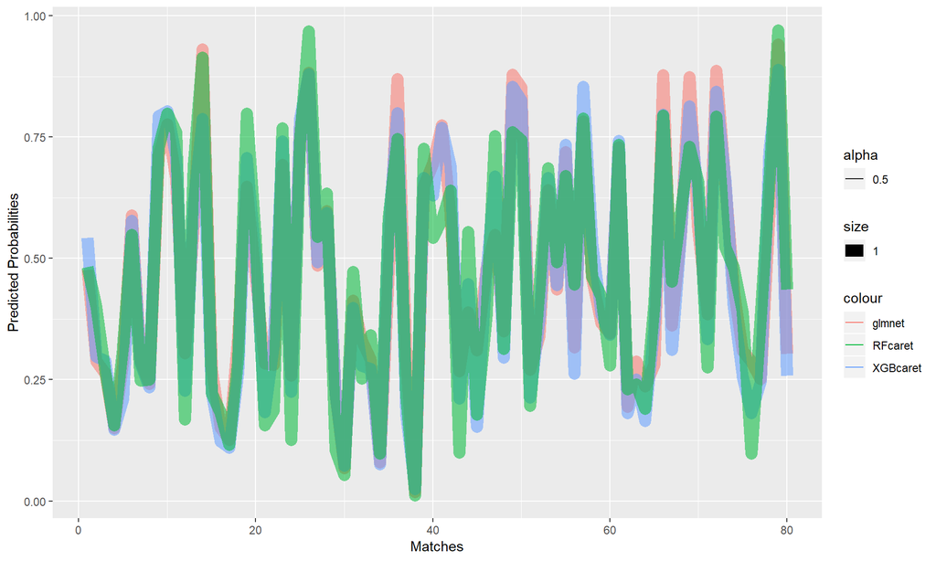

# 5. Conclusion and Future Work

Sports forecasting is trending and very important for many parties including sports fans, team managers, the media, sponsors regarding the monetary aspect of this industry. Therefore, the power of high accuracy forecasting will keep its importance in the future. The data driven predictions (without a bias of any individual) using the machine learning applications may be the future of sports forecasting.

In this project, three machine learning algorithms, (elastic net, random forest, stochastic gradient boosting) are applied to predict the home, tie, away probabilities of EPL matches played between 30.11.2018 and 03.01.2019. The basis data is the 1x2 type of odds set by 12 bookmakers (reduced from 27 regarding missing data threshold). In order to improve the model accuracy, 12 team specific features, showing the performances of teams in their home and away games, are added. Addition of these 12 parameters did not improve the model for elastic net algorithm, whereas better models are constructed for random forest and SGB algorithms.

One major conclusion is that when the home/tie/away prediction success of models are investigated, home and away predictions are more powerful than tie predictions. In other words, models are not capable of catching the tie ending games. The reason behind this issue may be the fact the problem is evaluated using classification approaches. The use of ordinal regression methods might improve tie predictions.

Another important result found by looking at the averages of the all played games is that probability of home team’s winning is higher than the other options. Higher motivation of teams’ playing in their own stadium with more motivated fans is probably the main reason behind this fact.

For future work, some other features may be added. One of them is the number of days passed since the last game of the teams’, which is a good indication of the level of tiredness of the teams. Another feature can be the ELO rating, the relative skill levels of teams. Some other features might be weather condition, the distance between the match place and teams’ home city. Moreover, adding a feature implementing the information of individual players’ performances like their physical and mental health conditions might also be an important feature for preidcting the match outcome.

[video not shown]

# 6. Codes

The main code is [Here](https://github.com/BU-IE-582/fall18-arcaserhat/blob/master/files/main.r)

The data preprocessing is done in [this function](https://github.com/BU-IE-582/fall18-arcaserhat/blob/master/files/data_preprocessing.r)

The feature extraction is done in [this function](https://github.com/BU-IE-582/fall18-arcaserhat/blob/master/files/feature_extraction.r)

The glm algorithm is run in [this function](https://github.com/BU-IE-582/fall18-arcaserhat/blob/master/files/train_models.r)

The xgboost algorithm is run in [this function](https://github.com/BU-IE-582/fall18-arcaserhat/blob/master/files/xgfunc.R)

The random forest algorithm is run in [this function](https://github.com/BU-IE-582/fall18-arcaserhat/blob/master/files/rffunc.R)

The model evaluation is done in [this function](https://github.com/BU-IE-582/fall18-arcaserhat/blob/master/files/performance_metrics.r)

# 7. References

• Baboota, R., Kaur, H., *Predictive analysis and modelling football results using machine learning approach for English Premier League.* International Journal of Forecasting, In press.

• Forrest, D., Goddard, J., Simmons, R., *Odds-setters as forecasters: The case of English football.* International Journal of Forecasting, 21: p.551-564, 2005.

• Goddord, J., and Asimakopoulos, I., *Forecasting football results and the efficiency of fixed-odds betting*. International Journal of Forecasting, 23: p.51-66, 2004.

• Hvattum, L.M., Arntzen, H., *Using ELO ratings for match result prediction in association football.* International Journal of Forecasting, 26: p.460-470, 2010.

• Leitner, C., Zeileis, A., Hornik, K., *Forecasting sports tournaments by ratings of (prob)abilities: A comparison for the EURO 2008.* International Journal of Forecasting, 26: p.471-481, 2010.

• Spann, M., Skiera, B., *Sports forecasting: a comparison of the forecast accuracy of prediction markets, betting odds and tipsters.* International Journal of Forecasting, 28: p.55-72, 2009.

• Strumbelj, E., Sikonja, M.,R., *Online bookmakers’ odds as forecasts: The case of European soccer leagues.* International Journal of Forecasting, 26: p.482-488, 2010.

• Strumbelj, E., *On determining probability forecasts from betting odds.* International Journal of Forecasting, 30: p.934-943, 2014.

• Suzuki, K., & Ohmori, K., *Effectiveness of FIFA/Coca-Cola World Ranking in predicting the results of FIFA World Cup finals.* Football Science, 5: p.18–25, 2008.

• Wunderlich, F., Memmert, D., *The Betting Odds Rating System: Using soccer forecasts to forecast soccer.* Plos One, 2018.